# cm006 Exercises: Exploring Geometric Objects

In this worksheet, we’ll be exploring various plot types (i.e., geometric objects), only using the `x` and `y` aesthetics (and `group`).

1. To get started, load the `tidyverse` and `gapminder` R packages.

```r
library(tidyverse)
library(gapminder)
```

## Scatterplot

Let’s look at a *scatterplot* of `gdpPercap` vs. `lifeExp`.

1. Fill out the grammar components below. Again, bold *must* be specified to make a `ggplot2` plot.
   - We’ll ignore “coordinate system” and “facetting” after this.

| Grammar Component | Specification |
| --- | --- |
| **data** | `gapminder` |
| **aesthetic mapping** | `x` and `y` |
| **geometric object** | point |
| scale | linear |
| statistical transform | none |
| coordinate system | rectangular |
| facetting | none |

2. Populate the data and aesthetic mapping in `ggplot`. What is returned? What’s missing?

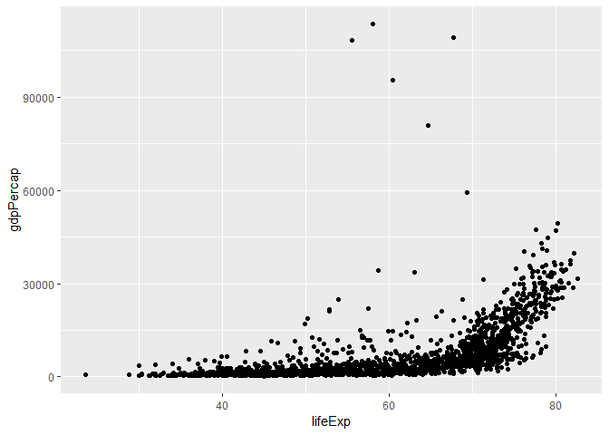

```r
ggplot(gapminder, aes(x=lifeExp,y=gdpPercap)) +  geom_point()
```

3. Add the missing component as a *layer*.

Notice the “metaprogramming” again!

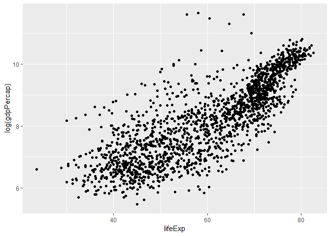

```r
ggplot(gapminder, aes(x=lifeExp, y=log(gdpPercap))) +geom_point()
```

6. Try again, this time by changing the *scale* (this way is better).

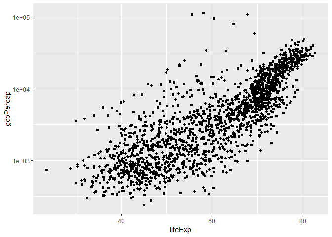

```r
ggplot(gapminder, aes(lifeExp, gdpPercap)) +geom_point()+
  scale_y_log10()
```

7. The aesthetic mappings can be specified on the geom layer if you want, instead of the main `ggplot` call. Give it a try:
8. Optional: git stage and commit

**Uses of a scatterplot**:

- Visualize 2-dimensional distributions; dependence.
- 2 numeric variables

## Histograms, and Kernel Density Plots

Let’s build a histogram of life expectancy.

1. Fill out the grammar components below. Again, bold *must* be specified to make a `ggplot2` plot.

| Grammar Component | Specification |
| --- | --- |
| **data** | `gapminder` |
| **aesthetic mapping** | `x` |
| **geometric object** | histogram |
| scale | linear |
| statistical transform | none |

2. Build the histogram of life expectancy.

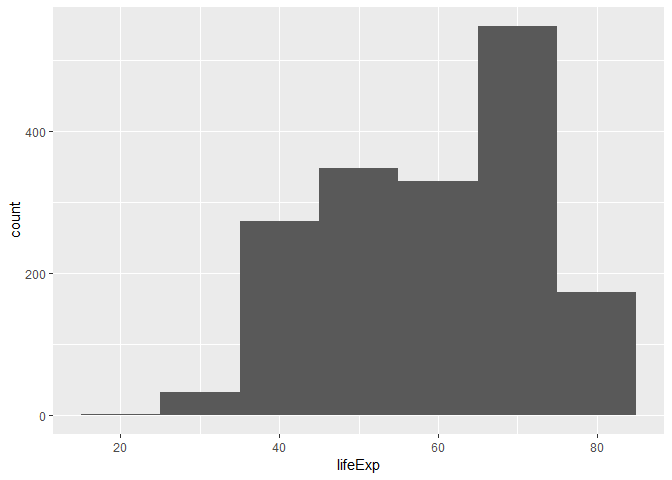

```r
ggplot(gapminder, aes(lifeExp))+
  geom_histogram(binwidth = 10)
```

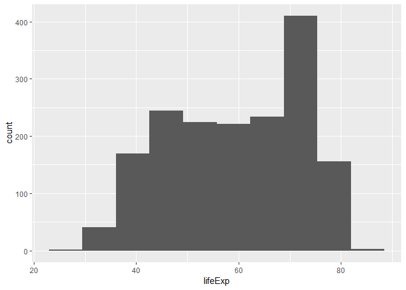

```r
ggplot(gapminder, aes(lifeExp))+
  geom_histogram(bins=10)
```

4. Instead of a histogram, let’s create a kernel density plot.

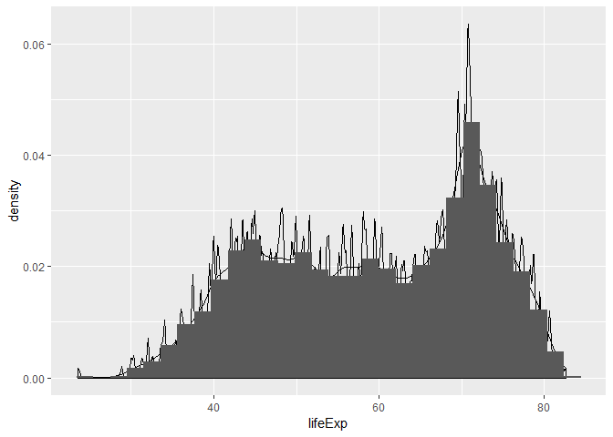

```r
ggplot(gapminder, aes(lifeExp))+
  geom_density(bw=1)+
  geom_density(bw=0.1)+
  geom_histogram(aes(y=..density..))
```

5. Optional: git stage and commit

**Uses of a histogram**: Explore the distribution of a single numeric variable.

## Box plots, and violin plots

Let’s make *box plots* of population for each continent. Note: y-axis is much better on a log scale!

1. Fill out the grammar components below. Again, bold *must* be specified to make a `ggplot2` plot.

| Grammar Component | Specification |
| --- | --- |
| **data** | `gapminder` |
| **aesthetic mapping** | `x` and `y` |
| **geometric object** | boxplot |
| scale | log-y |
| statistical transform | 5-number summary |

2. Initiate the `ggplot` call, with the log y scale, and store it in the variable `a`. Print out `a`.

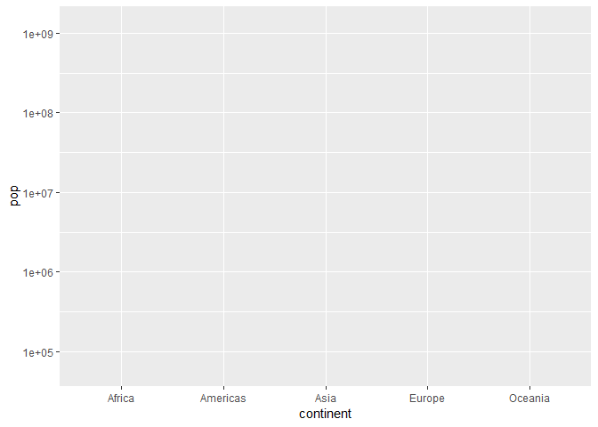

```r
a <- ggplot(gapminder, aes(continent, pop)) +
  scale_y_log10()
a
```

3. Add the boxplot geom to `a`.

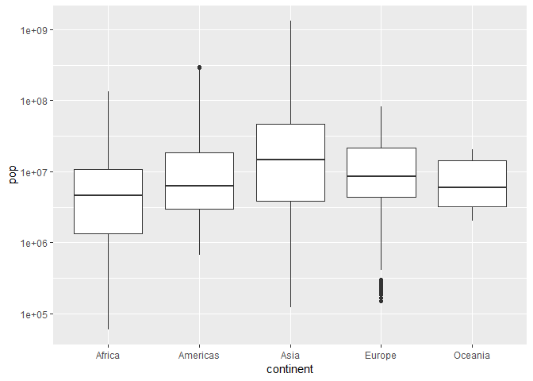

```r
a+ geom_boxplot()
```

4. A violin plot is a kernel density on its side, made symmetric. Add that geom to `a`.
   - What’s better here, boxplots or violin plots? Why?

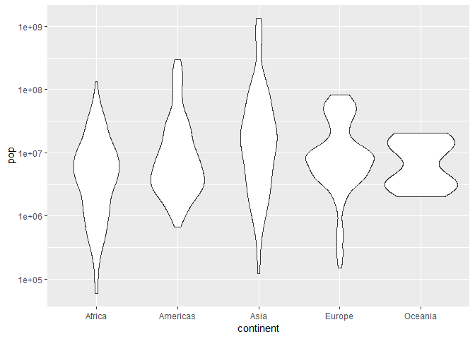

```r
a + geom_violin()
```

5. Optional: git stage and commit

**Use of boxplot**: Visualize 1-dimensional distributions (of a single numeric variable).

## Jitter plots

Let’s work up to the concept of a *jitter plot*. As above, let’s explore the population for each continent, but using points (again, with the y-axis on a log scale).

Let’s hold off on identifying the grammar.

1. Initiate the `ggplot` call to make a scatterplot of `continent` vs `pop`; initiate the log y scale. Store the call in the variable `b`.

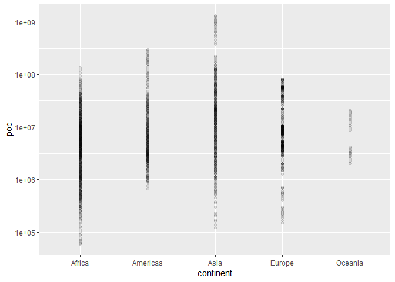

```r
a + geom_point(alpha=0.1)
```

2. Add the point geom to `b`. Why is this an ineffective plot?
3. A solution is to jitter the points. Add the jitter geom. Re-run the command a few times – does the plot change? Why?

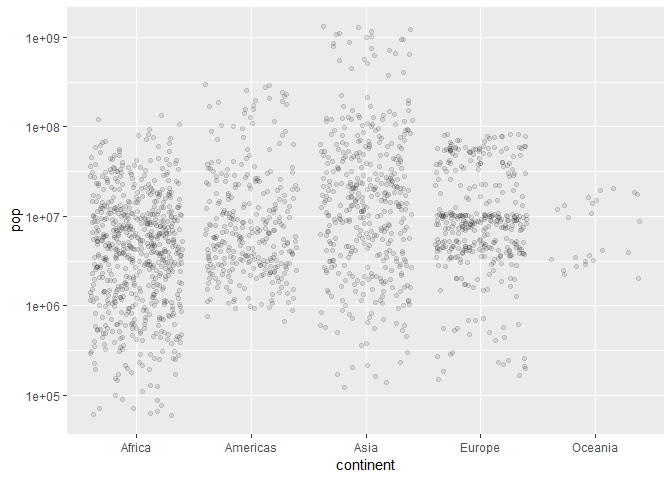

```r
a + geom_jitter(alpha=0.1)
```

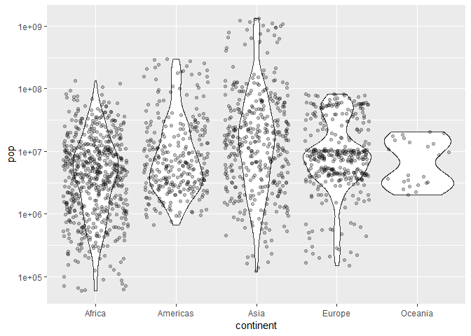

```r
a+ geom_violin()+
  geom_jitter(alpha=0.25)
```

6. Optional: git stage and commit

**Uses of jitterplot**: Visualize 1-dimensional distributions, AND get a sense of the sample size.

## Time/Line Plots

Let’s make some time/line plot, starting with Canada’s life expectancy over time.

1. Fill out the grammar components below. Again, bold *must* be specified to make a `ggplot2` plot.

| Grammar Component | Specification |
| --- | --- |
| **data** | `gapminder` |
| **aesthetic mapping** |  |
| **geometric object** |  |
| scale |  |
| statistical transform |  |

2. In one readable call, write code that:
   1. Filters the data to Canada only
   2. Pipes the filtered data into `ggplot`
   3. Makes the time plot of `lifeExp` over time
   4. Also displays the points

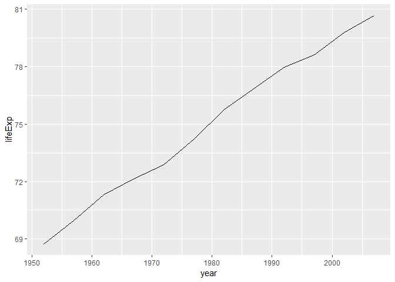

```r
gapminder %>%
  filter(country == "Canada") %>%
  ggplot(aes(year, lifeExp)) +
  geom_line()
```

3. Attempt to overlay line plots for all countries. That is, repeat the above code, but don’t filter. What’s wrong here?

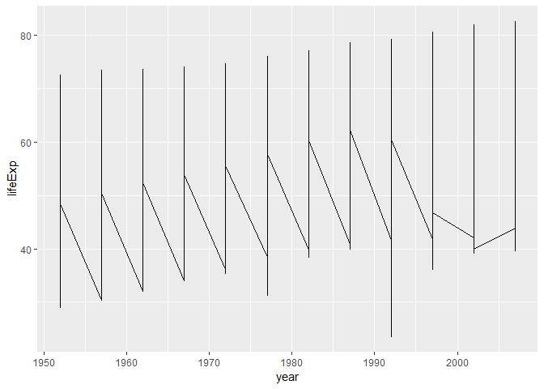

```r
c <- ggplot(gapminder, aes(year, lifeExp))
c+ geom_line()
```

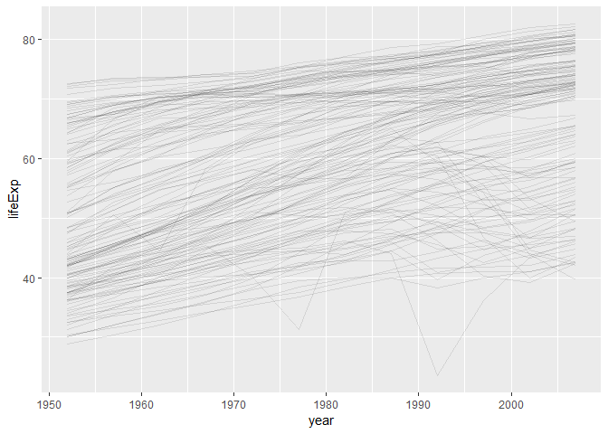

```r
c+geom_line(aes(group=country), alpha=0.1)
```

4. Use the `group` aesthetic to fix the problem.
5. Optional: git stage and commit

**Uses of time/line plots**: Visualize trends of a numeric variable over time.

## Path plots

Let’s see how Rwanda’s life expectancy and GDP per capita have evolved over time, using a path plot.

1. Make a scatterplot. Store it in the variable `c`.
2. We want to connect the dots from earliest point to latest. What happens if we add the “line” geom to `c`?
3. Add the appropriate geom to `c`. In that geom, specify a property of the geom: `arrow=arrow()`.
4. Optional: git stage and commit

**Uses of path plots**: The four “corners” of the plot usually indicate different qualities. This plot allows you to see how Rwanda (or some entity) evolves over these qualities.

## Bar plots

How many countries are in each continent? Use the year 2007.

1. Fill out the grammar components below. Again, bold *must* be specified to make a `ggplot2` plot.

| Grammar Component | Specification |
| --- | --- |
| **data** | `gapminder` |
| **aesthetic mapping** |  |
| **geometric object** |  |
| scale |  |
| statistical transform |  |

2. After filtering the gapminder data to 2007, make a bar chart of the number of countries in each continent. Store everything except the geom in the variable `d`.
3. Notice the y-axis. Oddly, `ggplot2` doesn’t make it obvious how to change to proportion. Try adding a `y` aesthetic: `y=..count../sum(..count..)`.
4. Optional: git stage, commit, and push!

**Uses of bar plots**: Get a sense of relative quantities of categories, or see the probability mass function of a categorical random variable.